# Money Ball

**This homework is due Sunday March 27, 2016 at 11:59PM EST. When complete, submit your code in an R Markdown file and the knitted HTML via GitHub.**

# Introduction

*Moneyball: The Art of Winning an Unfair Game* is a book by Michael Lewis about the Oakland Athletics baseball team and its general manager, the person tasked with building the team, Billy Beane. During Billy Bean’s tenure as general manager, ownership cut the budget drastically leaving Billy Bean with one of the lowest payrolls in baseball. Money Ball tells the story of how Billy Bean used analysts to find inefficiencies in the market. Specifically, his team used data science to find low cost players that the data predicted would help the team win. In this lab we will go back to 2002 and try to build a baseball team with a limited budget of $50,000,000. Note that in contrast to that Oakland A’s, the Yankees had a [budget](http://www.baseballchronology.com/Baseball/Years/2002/Payroll.asp) of more than double: $125,000,000

We will use the `Lahman` library as well as the usual `dplyr` and `ggplot2`. We also introduce the package `broom`.

```r
library(Lahman)
library(dplyr)
library(ggplot2)
library(broom)
```

You can see tables that are available when you load this package by typing

```r
?Lahman
```

# Problem 1 (80% of grade)

Statistics have been used in baseball since its beginnings. Note that `Lahman` goes back to the 19th century. Batting average, for example, has been used to summarize a batter’s success for decades. [Other statistics](http://mlb.mlb.com/stats/league_leaders.jsp) such as home runs, runs batted in (RBI) and stolen bases have been reported and players rewarded for high numbers. However, until [Bill James](https://en.wikipedia.org/wiki/Bill_James) introduced [sabermetrics](https://en.wikipedia.org/wiki/Sabermetrics), careful analyses had not been done to determine if these statistics actually help a team win. To simplify the exercise we will focus on scoring runs and ignore pitching and fielding.

## Problem 1A

Use the data in the `Team` table to explore the relationship between stolen bases and runs per game in 1999. Make a plot, fit a regression line, and report the coefficients. If you take the coefficient at face value, how many more runs per game does a team score for every extra SB per game?

```r
## Relationship between stolen bases [SB] and runs per game [R]
library(gridExtra)
```

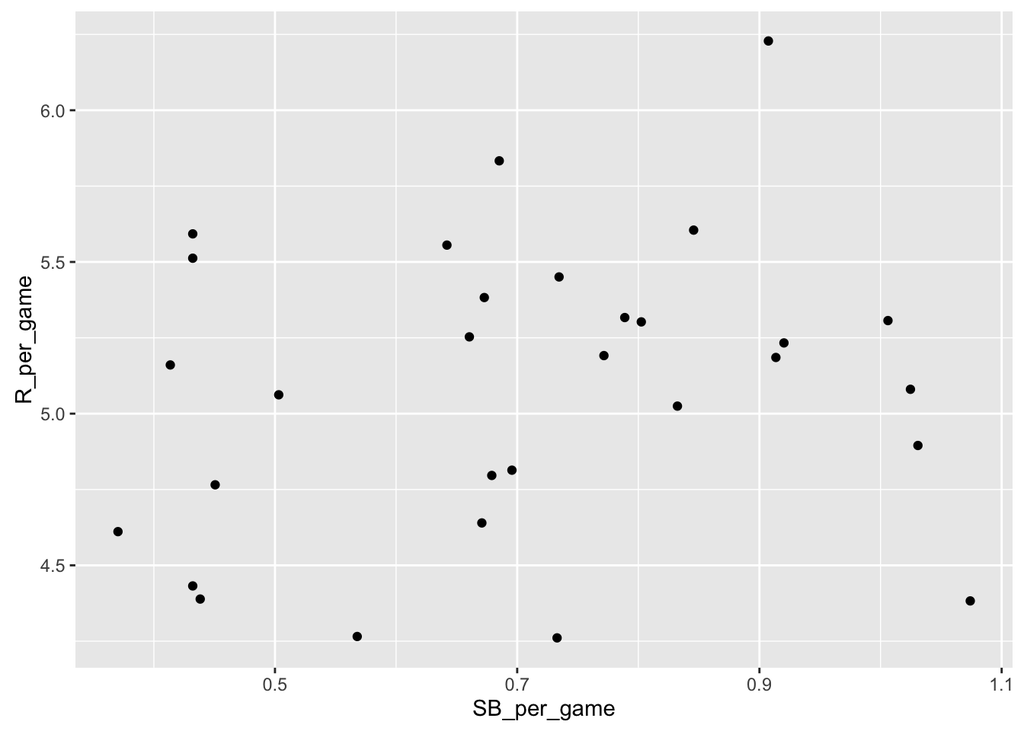

```r
tab <- Teams %>% filter(yearID == 1999 ) %>%
  mutate(R_per_game = R / G, SB_per_game = SB / G)

tab %>% ggplot(aes(SB_per_game, R_per_game)) + geom_point()
```

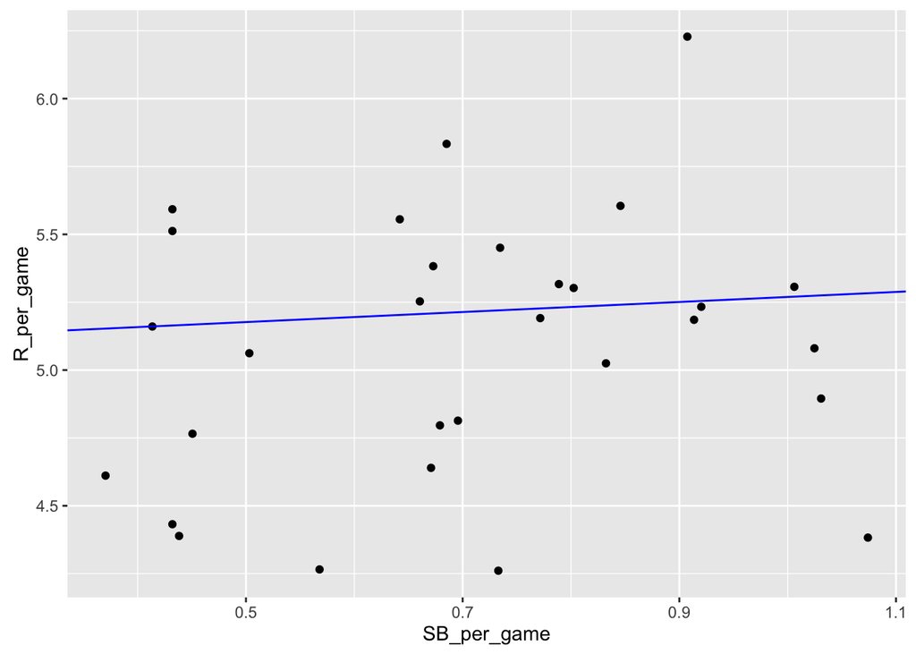

```r
#  + geom_abline(intercept = 0, slope = r , col="blue")

##Fit a regression line

r <- cor(tab$R_per_game, tab$SB_per_game) #Find the slope
mu_y <- mean(tab$R_per_game) # Find the Y intercept, on non-standardized data

tab %>% ggplot(aes(SB_per_game, R_per_game)) + geom_point() +
    geom_abline(intercept = mu_y, slope = r , col="blue")
```

```r
## Report coefficients
fit_1A <- tab %>% lm(SB_per_game ~ R_per_game, data=.)
fit_1A$coefficients
```

```
## (Intercept)  R_per_game
##  0.29873929  0.07978381
```

```r
summary(fit_1A)
```

```
##
## Call:
## lm(formula = SB_per_game ~ R_per_game, data = .)
##
## Residuals:
##      Min       1Q   Median       3Q      Max
## -0.31284 -0.17463  0.00142  0.10875  0.42567
##
## Coefficients:
##             Estimate Std. Error t value Pr(>|t|)
## (Intercept)  0.29874    0.40877   0.731    0.471
## R_per_game   0.07978    0.08005   0.997    0.327
##
## Residual standard error: 0.2076 on 28 degrees of freedom
## Multiple R-squared:  0.03426,    Adjusted R-squared:  -0.0002315
## F-statistic: 0.9933 on 1 and 28 DF,  p-value: 0.3275
```